# Week 2 Project

## The Mean and Median Number of Steps Taken Each Day

```r
mean <- mean(steps_date, na.rm = TRUE)
median <-median(steps_date, na.rm = TRUE)
vals <- c(mean,median)
title <- c("mean","median")
mmtable <- rbind(title,vals)
print(mmtable)
```

```
##       [,1]               [,2]
## title "mean"             "median"
## vals  "9354.22950819672" "10395"
```

## A time series plot of the average number of steps taken

I use Taply to create a data frame which describes the average steps at each 5 minute time interval.

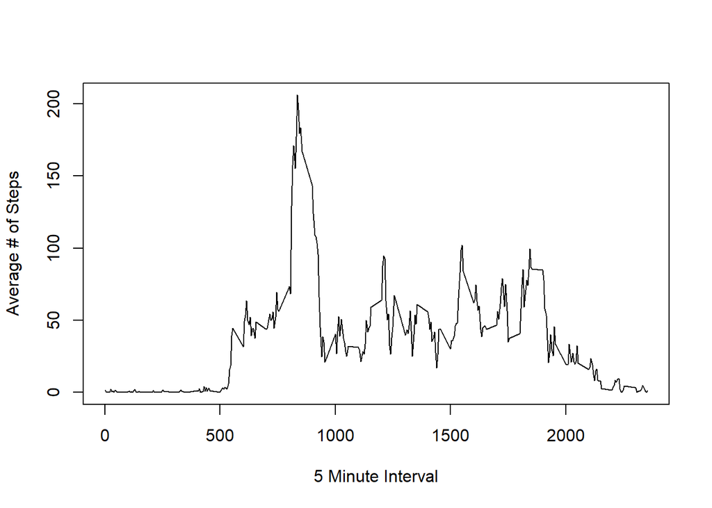

```r
steps_time <- tapply(activity$steps,activity$interval, FUN = mean, na.rm = TRUE)
ints <-  activity$interval[1:288]
steps_time_f <- cbind(steps_time,ints)
steps_time_f<- as.data.frame(steps_time_f)
plot(steps_time_f$ints,steps_time_f$steps_time, type = "l", xlab = "5 Minute Interval", ylab = "Average # of Steps")
```

## The 5-minute interval that, on average, contains the maximum number of steps

```r
maxinter <- max(steps_time_f$steps_time)
steptimesmax <- subset(steps_time_f, steps_time_f$steps_time== maxinter)
print(steptimesmax)
```

```
##     steps_time ints
## 835   206.1698  835
```

## Code to estimate the # of missing values

```r
missingv <- sum(is.na(activity$steps))
print(missingv)
```

```
## [1] 2304
```

## Code to describe and show a strategy for imputing missing data

I use Transform to replace all N.A values in the Steps aray of the Activity data frame with the average steps over the relevant time interval.

```r
activity_nar <- transform(activity, steps = ifelse(is.na(activity$steps), yes = steps_time_f$steps_time, no = activity$steps))
summary(steps_time_f)
```

```
##    steps_time           ints
##  Min.   :  0.000   Min.   :   0.0
##  1st Qu.:  2.486   1st Qu.: 588.8
##  Median : 34.113   Median :1177.5
##  Mean   : 37.383   Mean   :1177.5
##  3rd Qu.: 52.835   3rd Qu.:1766.2
##  Max.   :206.170   Max.   :2355.0
```

## A histogram of the total number of steps taken each day after missing values are imputed

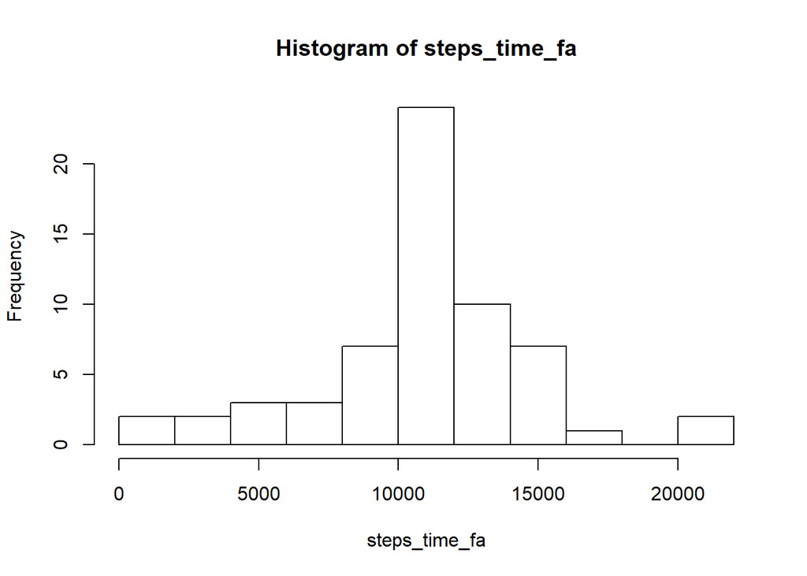

```r
steps_time_fa <- tapply(activity_nar$steps,activity_nar$date, FUN = sum)
hist(steps_time_fa, breaks =  10)
```

I used the wday function from the lubridate library to add a weekday array to my transformed activity data frame. I then used that frame to create two new objects; an activity data frame for weekdays, and an activity data frame for weekends. I then used the Tapply function to create two new arrays describing the average steps for each time interval within the weekend and weekeday arrayS, and plotted both of those series.

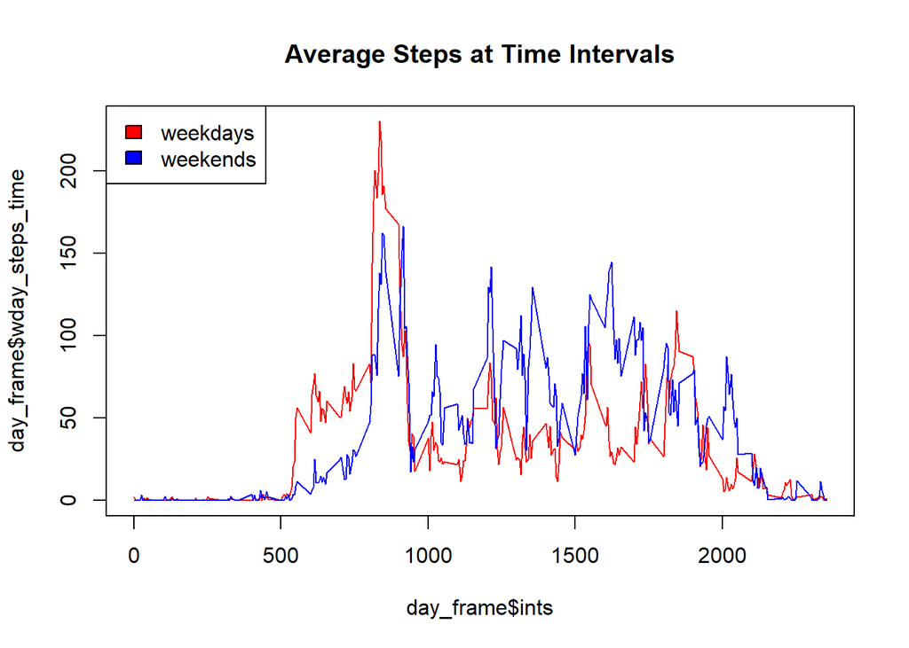

```r
activity_nar$wday <- wday(activity_nar$date)
activity_nar_wend <- subset(activity_nar, wday == 1 | wday == 7)
activity_nar_wday <- subset(activity_nar, wday != 1 & wday != 7)
wday_steps_time <- tapply(activity_nar_wday$steps,activity_nar_wday$interval, FUN = mean, na.rm = TRUE)
wend_steps_time <- tapply(activity_nar_wend$steps,activity_nar_wend$interval, FUN = mean, na.rm = TRUE)
day_frame <- as.data.frame( cbind(wday_steps_time,wend_steps_time,ints))
plot(day_frame$ints,day_frame$wday_steps_time, type = "l", col = "red")
lines(day_frame$ints,day_frame$wend_steps_time, col = "blue")
title(main = "Average Steps at Time Intervals")
legend("topleft",c("weekdays","weekends"),fill =c("red","blue"))
```